# The FLORSYS crop-weed canopy model, a tool to investigate and promote agroecological weed management - ScienceDirect

[figure not shown]

## Cited By (15)

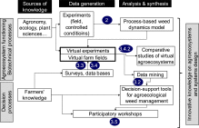

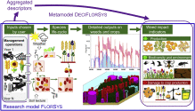

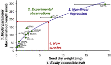

## Extras (1)

1. Document

[figure not shown]

## [Field Crops Research](https://www.sciencedirect.com/journal/field-crops-research)

[Volume 261](https://www.sciencedirect.com/journal/field-crops-research/vol/261/suppl/C), 1 February 2021, 108006

# The FLORSYS crop-weed canopy model, a tool to investigate and promote agroecological weed management

[NathalieColbach](https://www.sciencedirect.com/science/article/abs/pii/S0378429020312909#!)[FlorianeColas<sup>1</sup>](https://www.sciencedirect.com/science/article/abs/pii/S0378429020312909#!)[StéphaneCordeau](https://www.sciencedirect.com/science/article/abs/pii/S0378429020312909#!)[ThibaultMaillot](https://www.sciencedirect.com/science/article/abs/pii/S0378429020312909#!)[WilfriedQueyrel](https://www.sciencedirect.com/science/article/abs/pii/S0378429020312909#!)[JeanVillerd](https://www.sciencedirect.com/science/article/abs/pii/S0378429020312909#!)[DelphineMoreau](https://www.sciencedirect.com/science/article/abs/pii/S0378429020312909#!)

https://doi.org/10.1016/j.fcr.2020.108006[Get rights and content](https://s100.copyright.com/AppDispatchServlet?publisherName=ELS&contentID=S0378429020312909&orderBeanReset=true)

## Highlights

**•**

Crop diversification is essential for agroecological weed management.

**•**

Mechanistic weed models are crucial to synthesize knowledge on crop diversification.

**•**

Key processes are emergence, morphology, shade response and biophysical soil memory.

**•**

FLORSYS is used to track and promote crop [ideotypes](https://www.sciencedirect.com/topics/agricultural-and-biological-sciences/ideotype) and crop-diverse solutions.

**•**

Crop diversification benefits depend on production situations and cropping systems.

## Abstract

Crop diversification, both in time and in space, is essential for agroecological pest management. Process-based weed dynamics models are valuable tools to investigate this issue. Indeed, (1) weeds are the most harmful pest in arable crops and are essential for biodiversity, and (2) the processes driving crop-weed interactions are similar to those for crop-crop interactions in crop mixtures and crop rotations. Such models (3) synthesize existing and produce emergent knowledge on agroecological levers such as crop diversification, (4) mobilize this knowledge for cropping-system design, and (5) transfer research-based knowledge to stakeholders. The present paper illustrates these five items with the FLORSYS model. Its inputs are a detailed list of cultural operations over several years (crop succession including cover crops and crop mixtures, management techniques), together with daily weather data, soil characteristics and a regional weed species pool. FLORSYS runs at a daily time step, (1) focusing on processes leading to plant emergence and establishment of crop and weed species with different ecological requirements (essential for crops sown in different seasons and in mixtures where timing often determines the fate of a species), (2) representing and modelling the functioning of heterogeneous crop-weed canopies including diverse plant ages, morphologies and shade responses (as in crop mixtures), (3) including a carry-over effect on future cropping seasons (which is essential for crop rotations), and (4) assessing weed contribution to biodiversity. Detailed biophysical model outputs allow understanding the performance of a given crop, management technique or cropping system. Together with stakeholders, detailed model outputs were aggregated into indicators of crop production as well as weed benefits and harmfulness to simplify the multicriteria comparison of cropping systems. To facilitate decision support, FLORSYS was used as a virtual farm-field network, and the resulting simulation outputs were aggregated into a faster and easier-to-use metamodel (DECIFLORSYS) using machine learning techniques. These models were used to evaluate and promote the benefits of crop diversification for agroecological weed management, by (1) identifying crop ideotypes, (2) tracking crop-diverse solutions in farm-field networks, (3) evaluating crop-diverse solutions proposed by experts and stakeholders, and (4) feeding participatory workshops with farmers. The case studies demonstrate that the benefits of crop diversification depend on the production situations and cropping systems, and thus the need for flexible rules on crop diversification and the usefulness of models such as FLORSYS to establish these rules.

## Keywords

Ecological intensification

Mechanistic model

Biological interaction

Cropping system design

Cover crop

Intercropping

Rotation

Crop-weed competition

Ideotype

- 2022, European Journal of Agronomy

- 2021, Field Crops Research

- 2021, European Journal of Agronomy

- 2021, European Journal of Agronomy

- 2021, Ecological Modelling

- 2021, Field Crops Research

**<sup>1</sup>**

Present address: UMR 1132 LAE - AGISEM, Université de Lorraine, INRAE, 68000 Colmar, France

[View full text](https://www.sciencedirect.com/science/article/pii/S0378429020312909)

© 2020 Elsevier B.V. All rights reserved.

## Part of special issue:

[SI: Advances in crop modelling for ecological intensification](https://www.sciencedirect.com/science/journal/03784290/vsi/1082Z6Z3QTC)Edited by Marc Corbeels, Françoise Lescourret

[Download special issue](https://www.sciencedirect.com/science/journal/03784290/vsi/1082Z6Z3QTC)

- Field Crops Research, Volume 155, 2014, pp. 90-98

- Environmental Modelling & Software, Volume 86, 2016, pp. 184-203

- Ecological Modelling, Volume 384, 2018, pp. 221-232

[figure not shown]

[figure not shown]